# Reproducible Research (Course Project 1)

## Loading and Preprocessing the data

### 1. Load the data file “activity.csv” using read.csv.

```r
all_data  <- read.csv("./data/activity.csv", stringsAsFactors = F)
#displays first few rows of data
head(all_data)
```

```
##   steps       date interval
## 1    NA 2012-10-01        0
## 2    NA 2012-10-01        5
## 3    NA 2012-10-01       10
## 4    NA 2012-10-01       15
## 5    NA 2012-10-01       20
## 6    NA 2012-10-01       25
```

### 2. Process/transform the data (if necessary) into a format suitable for your analysis

Eliminate NA values from the data.

```r
complete_data <- all_data[complete.cases(all_data),]
```

## What is the mean total number of steps taken per day

### 1. Calculate the total number of steps per day

```r
totalSteps <- aggregate(steps~date, complete_data, sum)
names(totalSteps)[2] <- "total_steps" ##to add variable name for total steps per day
```

### 2. Make a histogram of the total number of steps taken per day

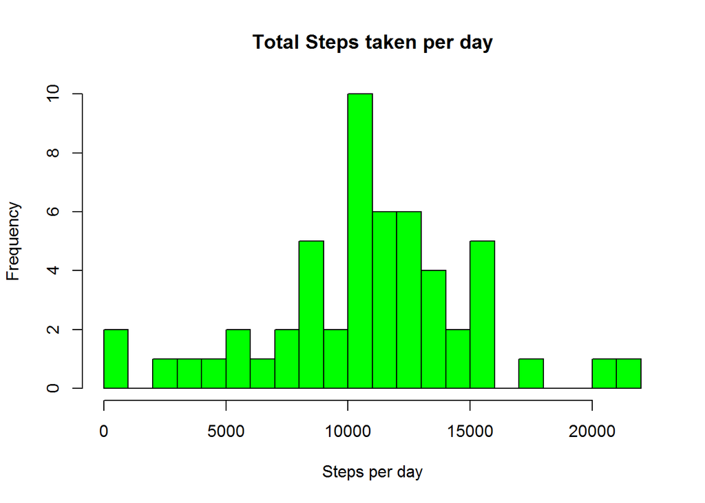

```r
hist(totalSteps$total_steps,col="green",
     main = "Total Steps taken per day",
     breaks=30,
     xlab="Steps per day",
     ylab = "Frequency")
```

### 3. Calculate and report the mean and median of the total number of steps per day

```r
mean_steps <- format(mean(totalSteps$total_steps),big.mark=",",nsmall=0)  #mean total steps per day
median_steps<-format(median(totalSteps$total_steps),big.mark=",", nsmall=0) #median total steps per day
```

The mean of total number of steps per day is 10,766.19

The median of total number of steps per day is 10,765

## What is the average daily activity pattern

### 1. Make a time series plot (i.e. type = “l”) of the 5-minute interval (x-axis) and the average number of steps taken, averaged across all days (y-axis)

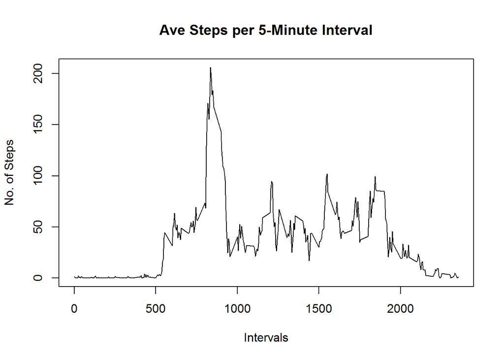

```r
interval_data <- aggregate(steps~interval, data=complete_data, mean)
plot(interval_data$interval,
     interval_data$steps,
     type="l",
     main="Ave Steps per 5-Minute Interval",
     xlab="Intervals",
     ylab="No. of Steps")
```

### 2. Which 5-minute interval, on average across all the days in the dataset, contains the maximum number of steps?

```r
#displays interval with maximum data steps on average
interval_data[interval_data$steps==max(interval_data$steps),]
```

```
##     interval    steps
## 104      835 206.1698
```

## Inputing missing values

### 1. Calculate and report the number of missing values in the dataset

```r
missing_data <- sum(is.na(all_data$steps))
```

There are 2304 rows with missing values in the dataset.

### 2. Devise a strategy for filling in all of the missing values in the dataset and create a new dataset that is equal to the original dataset but with the missing data filled in.

For this exercise, the strategy choses is to replace the missing values using the MEAN of steps per day. The following code creates a new data set using the original data set replacing the missing values with the mead data.

```r
##create copy of original data set
revised_data <- all_data

##Missing values with MEAN of steps data per day
revised_data$steps[is.na(revised_data$steps)] <- mean(all_data$steps, na.rm=TRUE)
head(revised_data)
```

```
##     steps       date interval
## 1 37.3826 2012-10-01        0
## 2 37.3826 2012-10-01        5
## 3 37.3826 2012-10-01       10
## 4 37.3826 2012-10-01       15
## 5 37.3826 2012-10-01       20
## 6 37.3826 2012-10-01       25
```

### 3. Make a histogram of the total number of steps taken each day and Calculate and report the mean and median total number of steps taken per day. Do these values differ from the estimates from the first part of the assignment?

Histogram of the total number of steps taken per day

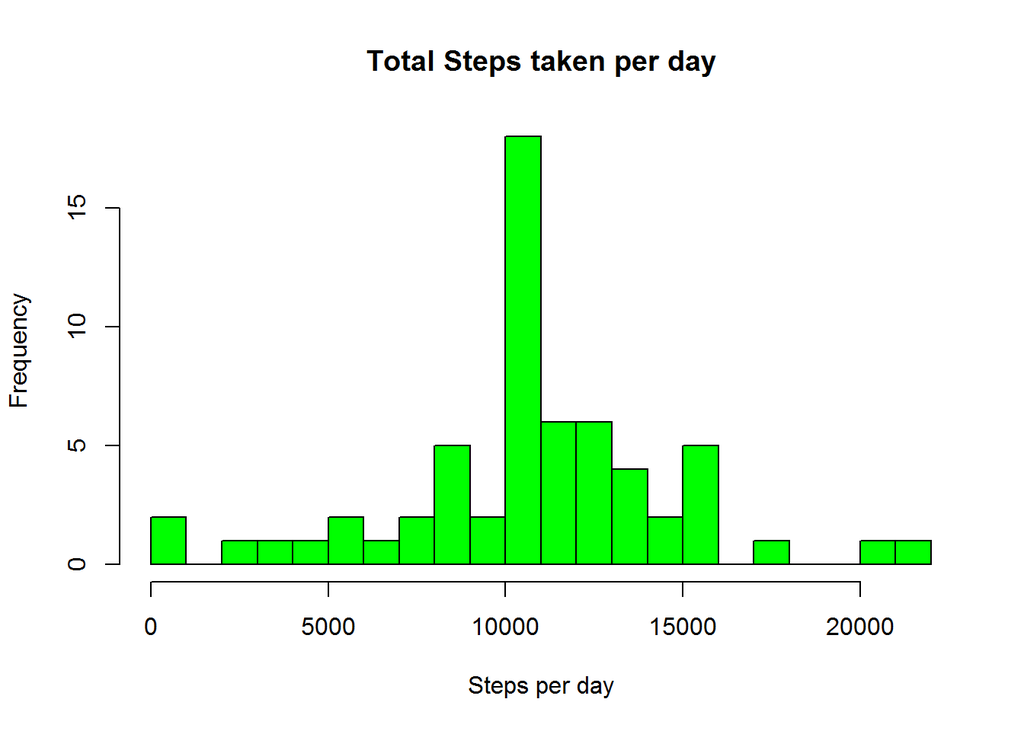

```r
totalSteps_new <- aggregate(steps~date, revised_data, sum)
names(totalSteps_new)[2] <- "total_steps" ##to add variable name for total steps per day
hist(totalSteps_new$total_steps,col="green",
     main = "Total Steps taken per day",
     breaks=30,
     xlab="Steps per day",
     ylab = "Frequency")
```

Report the mean and median total number of steps taken per day

```r
mean_steps_new <- format(mean(totalSteps_new$total_steps),big.mark=",",nsmall=0)  #mean total steps per day
median_steps_new<-format(median(totalSteps_new$total_steps),big.mark=",", nsmall=0) #median total steps per day
```

The mean of total number of steps per day is 10,766.19

The median of total number of steps per day is 10,766.19

Having used the MEAN daily values to replace the missing values, the mean remains the same, while the MEDIAN is now at 10,766.19 vs the former value of 10,765

## Are there differences in activity patterns between weekdays and weekends?

### 1. Create a new factor variable in the dataset with two levels - “weekday” and “weekend” indicating whether a given date is a weekday or weekend day.

```r
revised_data$date <- as.Date(revised_data$date)
revised_data$dayofweek <- weekdays(revised_data$date)
revised_data$daytype <- as.factor(ifelse(revised_data$dayofweek == "Saturday" |
                                 revised_data$dayofweek == "Sunday", "weekend", "weekday"))

head(revised_data) #displays head of revised dataset
```

```
##     steps       date interval dayofweek daytype
## 1 37.3826 2012-10-01        0    Monday weekday
## 2 37.3826 2012-10-01        5    Monday weekday
## 3 37.3826 2012-10-01       10    Monday weekday
## 4 37.3826 2012-10-01       15    Monday weekday
## 5 37.3826 2012-10-01       20    Monday weekday
## 6 37.3826 2012-10-01       25    Monday weekday
```

### 2. Make a panel plot containing a time series plot (i.e. type = “l”) of the 5-minute interval (x-axis) and the average number of steps taken, averaged across all weekday days or weekend days (y-axis).

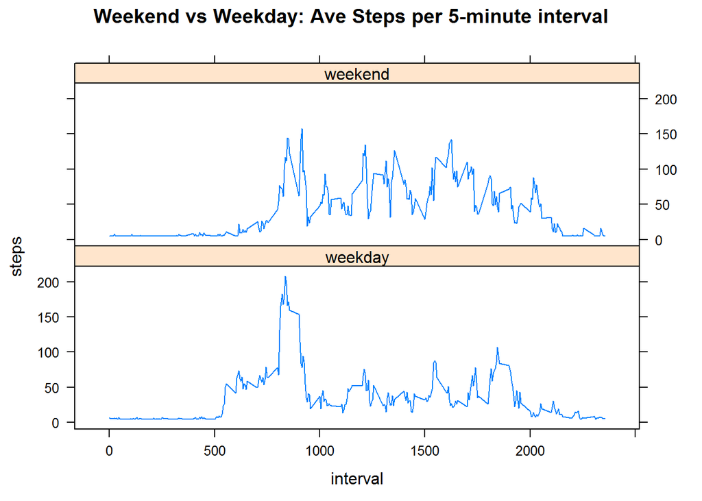

```r
library(lattice)
stepsdata <- aggregate(steps ~ interval + daytype, revised_data, mean)
xyplot(steps ~ interval | factor(daytype),
       data=stepsdata,
       layout = c(1,2),
       type="l",
       main="Weekend vs Weekday: Ave Steps per 5-minute interval")
```